# 2-Sample t Review

Review 2-Sample t-test, with a few twists.

# Introduction

A two-sample t-test is a statistical method for comparing the means of a quantitative variable between two populations represented by two independent samples. The [specific details of a two-sample t-test were covered in your introductory statistics course](http://derekogle.com/NCMTH107/modules/2Samplet.html) and will only be cursorily reviewed here.

The null hypothesis for a 2-sample t-test is H<sub>0</sub>: μ<sub>1</sub>=μ<sub>2</sub>, where μ is the population mean and the subscripts represent the two populations. The alternative hypothesis of a 2-sample t-test may be “less than”, “greater than”, or “not equals”. We will use H<sub>A</sub>: μ<sub>1</sub>≠μ<sub>2</sub> for most examples in this course.

Hypotheses

Assumptions

$$s_{p}^{2}=\frac{(n_{1}-1)s_{1}^{2}+(n_{2}-1)s_{2}^{2}}{n_{1}+n_{2}-2}$$

If the three assumptions are met then the statistic for the 2-sample t-test is $\bar{x}_{1}-\bar{x}_{2}$ which is immediately standardized to a t test statistic with

Statistic and test statistic

$$t=\frac{\bar{x}_{1}-\bar{x}_{2}}{\sqrt{s_{p}^{2}\left(\frac{1}{n_{1}}+\frac{1}{n_{2}} \right)}}$$

The t test statistic is converted to a p-value using a t-distribution with n<sub>1</sub>+n<sub>2</sub>-2 df. Of course, a p-value < α means that H<sub>0</sub> is rejected and the two population means appear to be different. A confidence interval would then be used to fully describe which population mean was greater (or smaller) and by how much.

p-value and decision

# Analysis in R

### Data Format

Data for a 2-sample t-test must be in stacked format, where measurements are in one column and a label for the populations is in another column. Each row corresponds to the measurement and population of a single individual.

MUST use stacked data

The data ([data](https://raw.githubusercontent.com/droglenc/NCData/master/BOD.csv), [meta](https://github.com/droglenc/NCData/blob/master/BOD_meta.txt)) for the example below are the [biological oxygen demands (BOD)](https://www.usgs.gov/special-topic/water-science-school/science/biological-oxygen-demand-bod-and-water?qt-science_center_objects=0#qt-science_center_objects) at the inlet and outlet to an aquaculture facility. These data illustrate stacked data because each row is one water sample with two variables recorded – BOD and where the sample came from.

```
aqua <- read.csv("BOD.csv")
```

```
headtail(aqua)
```

```
#R>        BOD    src
#R>   1  6.782  inlet
#R>   2  5.809  inlet
#R>   3  6.849  inlet
#R>   18 8.545 outlet
#R>   19 8.063 outlet
#R>   20 8.001 outlet
```

Specific [details for performing a 2-sample t-test in R](http://derekogle.com/NCMTH107/modules/2Samplet.html) were provided in your introductory statistics course, but will be cursorily reviewed below.

### Assumption Checking

The metadata suggests that measurements at the intake and outtake were taken at different times. Thus, there is no reasonable reason to think that individuals are dependent across the two populations. Thus, the independence assumption is met.

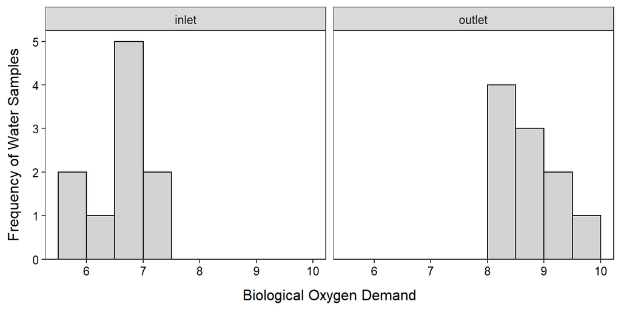

```
ggplot(data=aqua,mapping=aes(x=BOD)) +
  geom_histogram(binwidth=0.5,boundary=0,color="black",fill="lightgray") +
  labs(y="Frequency of Water Samples",x="Biological Oxygen Demand") +
  scale_y_continuous(expand=expansion(mult=c(0,0.05))) +
  theme_NCStats() +
  facet_wrap(vars(src))
```

Levene’s test is computed with `levenesTest()` using a formula of `response~groups` as the first argument, where `response` represents the name of the quantitative response variable and `groups` represents the name of the categorical variable that identifies the two populations. The data.frame with the variables must be in `data=`. From the results below, it is concluded that the population variances appear to be equal because the Levene’s test p-value (0.5913) is greater than α=0.05.

```
levenesTest(BOD~src,data=aqua)
```

```
#R>   Levene's Test for Homogeneity of Variance (center = median)
#R>         Df F value Pr(>F)
#R>   group  1  0.2989 0.5913
#R>         18
```

### Analysis

A 2-sample t-test is constructed in R with `t.test()` using the exact same `response~groups` formula and `data=` used in `levenesTest()`. Additionally, `var.equal=TRUE` is used when the two population variances should be considered equal. By default `t.test()` uses a “not equals” H<sub>A</sub> and a 95% confidence interval. In the results below the two sample means are 6.6538 for the inlet group and 8.6873 for the outlet group such that the statistic is 6.6538-8.6873=-2.0335; the t test statistic is -8.994 with 18 df; and the p-value is <0.00005 (or, more specifically, 4.449e-08).[^1] Because the p-value<α the H<sub>0</sub> is rejected and we conclude that the mean BOD at the inlet is lower than the mean BOD at the outlet. More specifically, the mean BOD at the inlet is between 1.558 and 2.509 units lower than the mean BOD at the outlet. Thus, it appears that the mean BOD in the water is increased from when it enters to when it leaves the aquaculture facility.

```
t.test(BOD~src,data=aqua,var.equal=TRUE)
```

```
#R>    Two Sample t-test with BOD by src
#R>   t = -8.994, df = 18, p-value = 4.449e-08
#R>   alternative hypothesis: true difference in means is not equal to 0
#R>   95 percent confidence interval:
#R>    -2.508511 -1.558489
#R>   sample estimates:
#R>    mean in group inlet mean in group outlet
#R>                 6.6538               8.6873
```

A graphic that illustrates the mean BOD with 95% confidence intervals for each sampling location is constructed below.

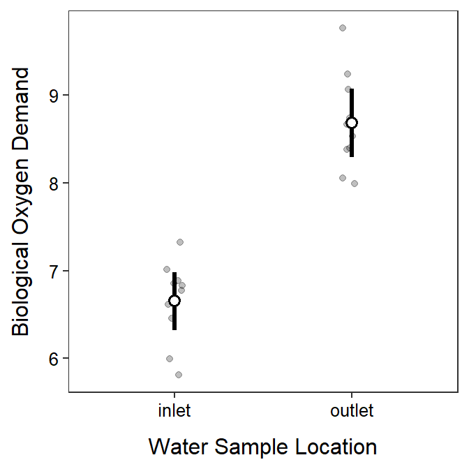

```
ggplot(data=aqua,mapping=aes(x=src,y=BOD)) +
  geom_jitter(alpha=0.25,width=0.05) +
  stat_summary(fun.data=mean_cl_normal,geom="pointrange",
               size=1.1,fatten=2,pch=21,fill="white") +
  labs(y="Biological Oxygen Demand",x="Water Sample Location") +
  theme_NCStats()
```

# Signal-to-Noise

The ratio of signal to noise can be a useful metaphor for understanding hypothesis testing, as we have done here, and model comparisons, as we will do in future modules. In this metaphor, think of “signal” as how different two things are and “noise” as anything that gets in the way of you receiving the signal. For example, the difference in heights of two students standing on the other side of the room is a “signal”, but smoke in the room that makes it difficult to see those students is “noise.” As another example, it may be easy to see an orange kayak (the “signal”) on Lake Superior on a calm day but harder to see it on a wavy day (i.e., more “noise”).

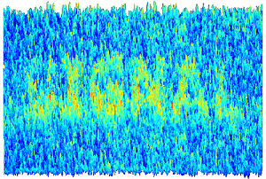

In a 2-sample t-test, the “signal” is the difference in the two group means (Figure 1), which is measured by $\bar{x}_{1}-\bar{x}_{2}$, the numerator of the t-test statistic. The bigger the difference in sample means the stronger the “signal” that the population means are different.

“Signal” is the difference in sample means

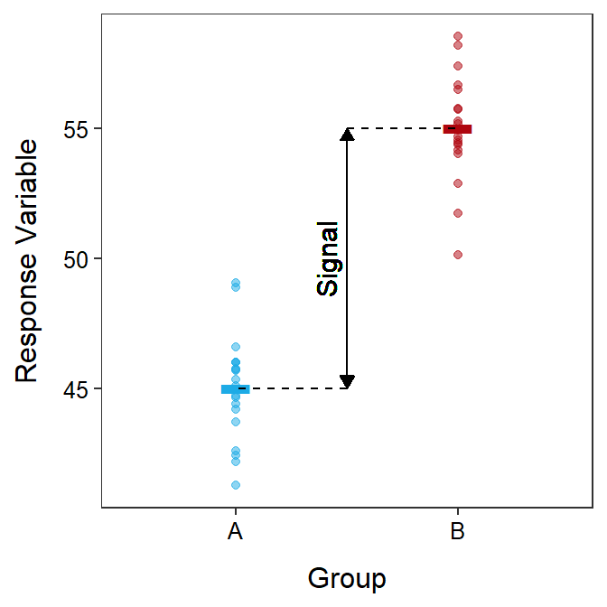

Figure 1: Response variable by group for each indiviual (points) with group means shown as horizontal segments. The difference in sample means is highlighted as the “signal” in these data.

“Noise” is sampling variability, the fact that statistics (e.g., $\bar{x}_{1}$ and $\bar{x}_{2}$) vary from sample to sample. Sampling variability in a 2-sample t-test is measured by $SE_{\bar{x}_{1}-\bar{x}_{2}}$, which is the denominator of the t test statistic, or $\sqrt{s_{p}^{2}\left(\frac{1}{n_{1}}+\frac{1}{n_{2}}\right)}$. This SE increases with increasing $s_{p}^{2}$ and decreases with increasing n<sub>1</sub> and n<sub>2</sub>. So the “noise” increases as the natural variability of individuals around their group means (i.e., $s_{p}^{2}$) increases (Figure 2), but decreases as the sample size increases.

“Noise” is sampling variability

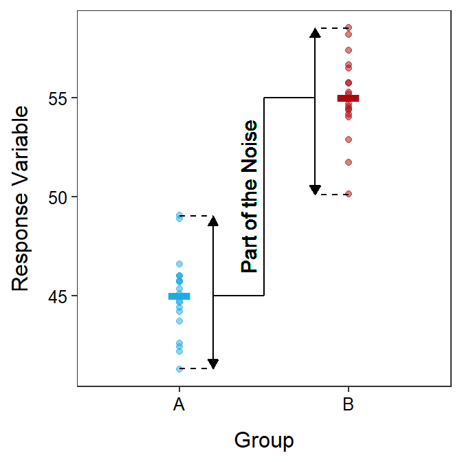

Figure 2: Response variable by group for each indiviual (points) with group means shown as horizontal segments. The variability of individuals around the group means is highlighted as a part of the “noise” in these data.

The ratio of signal to noise is related to whether we will be able to detect the difference between two things or not. If the signal is large relative to the noise then the signal will be detected. In other words, will be able to tell the difference in heights of students if the room is not full of smoke.

For example, each panel in Figure 3 has the same signal (difference in means) but the noise (i.e., SE) increases from left to right. In the left-most panel it is very clear that the sample means are different (high signal-to-noise ratio), but in the right-most panel it is less clear that the sample means are different (low signal-to-noise ratio).

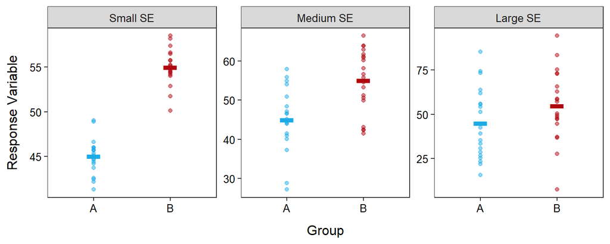

Figure 3: Response variable by group for each indiviual (points) with group means shown as horizontal segments for three different standard errors (SE; i.e., “noise”). Note that the group means are the same in all three panels.

The t test statistic is a measure of signal (i.e., difference in sample means) to noise (i.e., sampling variability as measured by the SE)

$$t=\frac{\bar{x}_{1}-\bar{x}_{2}}{\sqrt{s_{p}^{2}\left(\frac{1}{n_{1}}+\frac{1}{n_{2}} \right)}} = \frac{\text{Signal}}{\text{Noise}}$$

Thus, larger values of the t test statistic indicate a larger signal-to-noise ratio. Larger t test statistics are further into the tail of the t distribution and result in smaller p-values. Therefore, small p-values represent larger signal-to-noise ratios and are more likely to lead to concluding that the population means differ. In other words, you were able to detect the “signal” through the “noise.”

More signal-to-noise means smaller p-values

We will return to the signal-to-noise metaphor throughout this course.

# Corrections

If you see any errors (code, typographical, or logical) please bring these to my attention.

[^1]: I usually round my p-values to four decimal places. In this case that would mean 0.0000 which is awkward. Thus, I will say p<0.00005 as the fifth position must have been less than 5 to round to 0.0000.